# Getting Started in iglu

# Calculating time-dependent metrics

Unlike time-independent metrics, time-dependent metrics require the input to be a dataframe with subject id’s, time, and glucose values. Time-dependent metric functions cannot be passed a vector of glucose values. With timestamped data, a potential challenge arises when timestamps are not on perfect intervals due to missing measurements. To address this challenge, we developed the `CGMS2DayByDay` function.

## CGMS2DayByDay()

```r
str(CGMS2DayByDay(example_data_1_subject))
```

```
#> List of 3
#>  $ gd2d        : num [1:14, 1:288] NA 112.2 92 90.1 143.1 ...
#>  $ actual_dates: Date[1:14], format: "2015-06-06" "2015-06-07" ...
#>  $ dt0         : num 5
```

The first part of the output, `gd2d`, is the interpolated grid of values. Each row corresponds to one day of measurements, and the columns correspond to an equi-distant time grid covering a 24 hour time span. The grid is chosen to match the frequency of the sensor (5 minutes in this example leading to $(24 * 60)/ 5 = 288$ columns), which is returned as `dt0`. The returned `actual_dates` allows one to map the rows in `gd2d` back to the original dates. The achieved alignment of glucose measurement times across the days enables both the calculation of corresponding metrics, and the creation time-dependent visuals such as lasagna plots. The default frequency can be adjusted as follows.

```r
str(CGMS2DayByDay(example_data_1_subject, dt0 = 10))
```

```
#> List of 3
#>  $ gd2d        : num [1:14, 1:144] NA 111.1 92.9 89.1 138.2 ...
#>  $ actual_dates: Date[1:14], format: "2015-06-06" "2015-06-07" ...
#>  $ dt0         : num 10
```

Note that the final part of the output reflects our input, and there are now only 144 columns instead of 288.

The CGMS2DayByDay function also allows specification of the maximum allowable gap to interpolate values across (default is 45 minutes) and a string corresponding to time zone (default is the timezone of the user’s system).

Functions for metrics requiring linear interpolation will accept the following three parameters that are passed on to `CGMS2DayByDay()`:

- “`dt0`” - Time frequency (numeric) for interpolation. Default will automatically match the frequency of the data
- “`inter_gap`” - Maximum allowable gap in minutes (numeric) for interpolation
- “`tz`” - String corresponding to timezone where the data’s measurements were recorded

In the example_data_5_subject dataset, it is important to specify `tz` = ‘EST’, because a Daylight Savings Time shift can cause miscalculations if the wrong timezone is used. A proper call for this dataset, being recorded in EST, would be:

```r
CGMS2DayByDay(example_data_1_subject, tz = 'EST')
```

Examples of proper metric function calls will be shown in the next section.

## Example metrics: time-dependent

Some metric functions, like `conga()` (Continuous Overlapping Net Glycemic Action), will return just a single value for each subject, resulting in a 2 column tibble (1 column for id and 1 for the single value).

```r
conga(example_data_1_subject, tz = 'EST')
```

```
#> # A tibble: 1 × 2
#>   id        CONGA
#>   <fct>     <dbl>
#> 1 Subject 1  37.0
```

Other metrics can return multiple values for a single subject. For example, `sd_measures()`, which requires linear interpolation, computes 6 unique standard deviation subtypes per subject.

```r
sd_measures(example_data_5_subject)
```

```
#> # A tibble: 5 × 7
#>   id          SDw SDhhmm SDwsh  SDdm   SDb SDbdm
#>   <fct>     <dbl>  <dbl> <dbl> <dbl> <dbl> <dbl>
#> 1 Subject 1  26.4   19.6  6.54  16.7  27.9  24.0
#> 2 Subject 2  36.7   22.8  7.62  52.0  48.0  35.9
#> 3 Subject 3  42.9   14.4  9.51  12.4  42.8  42.5
#> 4 Subject 4  24.5   12.9  6.72  16.9  25.5  22.0
#> 5 Subject 5  50.0   29.6 12.8   23.3  50.3  45.9
```

Notice the high fluctuations in Subject 5, with all but one subtypes of standard deviation being the largest for Subject 5. This provides additional level of CGM data interpretation, since frequent or large glucose fluctuations may contribute to diabetes-related complications independently from chronic hyperglycemia.

# Calculating metrics for sleep or wake periods

Iglu provides a function for calculating metrics over a given time-range. The calculate_sleep_wake function allows the user to apply an arbitrary function to given data after it has been filtered by time of day. It supports calculating on inside the time range, outside the time range, or both separately.

## Using calculate_sleep_wake

To use this function, pass it the data you want and the function or name of the function you want to apply. For example, to calculate the standard deviation of glucose readings from 12-6am, the function’s default time period, the following call will work.

```r
calculate_sleep_wake(example_data_1_subject, sd_glu, calculate = "sleep")
```

```
#> # A tibble: 1 × 2
#>   id           SD
#>   <fct>     <dbl>
#> 1 Subject 1  25.4
```

A custom time period can be defined with the sleep_start and sleep_end parameters. The values of these parameters should be real numbers between 0-24. If an integer is passed to sleep_start, the whole hour will be included. If an integer is passed to sleep_end, everything up to but not including that hour will be included. The following call will calculate the metrics for readings between 2:00-7:59am.

```r
calculate_sleep_wake(example_data_5_subject, sd_measures, sleep_start = 2, sleep_end = 8, calculate = "sleep")
```

```
#> # A tibble: 5 × 7
#>   id          SDw SDhhmm SDwsh  SDdm   SDb SDbdm
#>   <fct>     <dbl>  <dbl> <dbl> <dbl> <dbl> <dbl>
#> 1 Subject 1  10.2   3.04  3.15  21.3  23.9  12.2
#> 2 Subject 2  18.9  12.8   6.22  41.9  43.6  18.2
#> 3 Subject 3  17.6   9.99  4.86  20.1  32.7  26.8
#> 4 Subject 4  10.8   3.98  3.43  12.2  17.3  12.0
#> 5 Subject 5  28.1  13.3   5.88  29.4  38.4  27.2
```

There is an option to calculate for either sleep, wake, or both periods. By default, the metric will be calculated for the sleep period. To calculate for the wake period, set the “calculate” parameter to “wake”. The following call will calculate the metric for all readings outside of 11pm-6:59am

```r
calculate_sleep_wake(example_data_5_subject, grade, sleep_start = 23, sleep_end = 7, calculate = "wake")
```

```
#> # A tibble: 5 × 2
#>   id        GRADE
#>   <fct>     <dbl>
#> 1 Subject 1  4.44
#> 2 Subject 2 15.5
#> 3 Subject 3  7.28
#> 4 Subject 4  3.51
#> 5 Subject 5 11.7
```

To calculate for sleep and wake periods separately and return both of those values, labeled accordingly, set the ‘calculate’ parameter to ‘both’.

```r
calculate_sleep_wake(example_data_5_subject, gmi, calculate = "both")
```

```
#> # A tibble: 5 × 3
#>   id        `GMI sleep` `GMI wake`
#>   <fct>           <dbl>      <dbl>
#> 1 Subject 1        5.97       6.41
#> 2 Subject 2        8.58       8.52
#> 3 Subject 3        7.05       6.98
#> 4 Subject 4        6.70       6.31
#> 5 Subject 5        6.94       7.69
```

Custom parameters can still be passed to the applied function. Any parameters with different names from calculate_sleep_wake’s parameters will be passed on to the function. The following call applies COGI with the custom defined targets and weights.

```r
calculate_sleep_wake(example_data_5_subject, cogi, calculate = "sleep", targets = c(80, 150), weights = c(.3,.2,.5))
```

```
#> # A tibble: 5 × 2
#>   id         COGI
#>   <fct>     <dbl>
#> 1 Subject 1  91.5
#> 2 Subject 2  52.4
#> 3 Subject 3  77.8
#> 4 Subject 4  89.4
#> 5 Subject 5  63.9
```

All of these options can be combined

```r
calculate_sleep_wake(example_data_5_subject, grade_eugly, sleep_start = 1, sleep_end = 9, calculate = "both", lower = 80, upper = 150)
```

```
#> # A tibble: 5 × 3
#>   id        `GRADE_eugly sleep` `GRADE_eugly wake`
#>   <fct>                   <dbl>              <dbl>
#> 1 Subject 1               59.0               31.0
#> 2 Subject 2                1.32               1.38
#> 3 Subject 3               41.0               21.6
#> 4 Subject 4               55.7               37.4
#> 5 Subject 5               25.3                6.99
```

# Visualizations

The iglu package supports multiple plot types summarized below:

| Function call | Visualization description | Main parameters |
| --- | --- | --- |
| `plot_glu` | Multiple plot types: time series and lasagna | `plottype`, `lasagnatype` |
| `plot_roc` | Time series of glucose values colored by rate of change (ROC) | `subjects`, `timelag` |
| `hist_roc` | Histogram of rate of change (ROC) values | `subjects`, `timelag` |
| `plot_lasagna` | Lasagna plot of glucose values for multiple subjects | `datatype`, `lasagnatype` |
| `plot_lasagna_1subject` | Lasagna plot of glucose values for a single subject | `lasagnatype` |
| `agp` | Ambulatory Glucose Profile (AGP) | `maxd`, `daily` |
| `epicalc_profile` | Profile of glycemic episodes | `hypo_thresh`, `hyper_thresh` |
| `mage` | MAGE plot displaying peaks and nadirs | `plot`, `title` |

Time-series and rate of change plots are shown in examples below. For details on the other plotting types, see the specific vignette corresponding to the visualization.

## Example plots: time-series

The simplest visual is the time series plot generated using the function `plot_glu`. This plot type can support both single and multiple subjects.

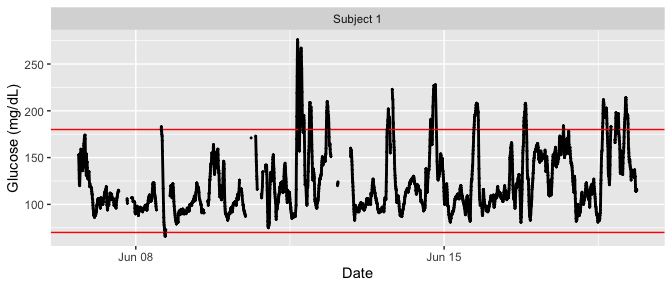

```r
plot_glu(example_data_1_subject, plottype = 'tsplot', tz = "EST")
```

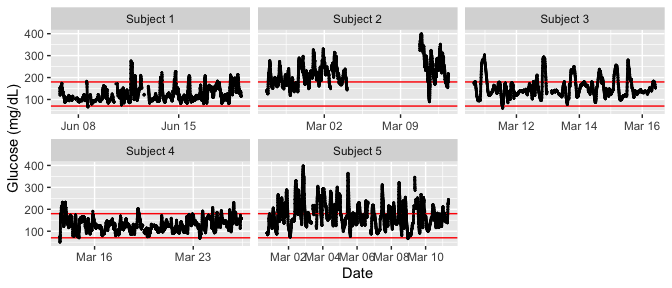

```r
plot_glu(example_data_5_subject, plottype = 'tsplot', tz = "EST")
```

We set the ‘tz’ (timezone) parameter to be EST because the data was collected in the eastern time zone. If left blank, the time zone used for plotting will be the system’s time zone. Time zone is mainly an issue in cases where daylight savings time might make it appear as though there were duplicate values at some time points.

To just plot a single subject of interest from the grid of time series plots, set the ‘subjects’ parameter to be that subject’s ID.

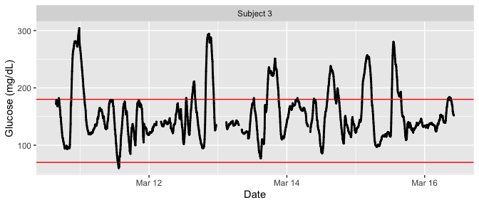

```r
plot_glu(example_data_5_subject, plottype = 'tsplot', subjects = 'Subject 3', tz = "EST")
```

The red lines can be shifted to any Lower and Upper Target Range Limits with the ‘LLTR’ and ‘ULTR’ arguments.

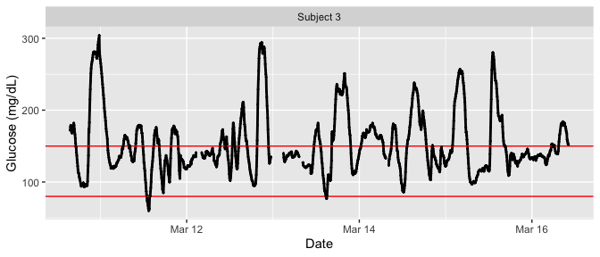

```r
plot_glu(example_data_5_subject, plottype = 'tsplot', subjects = 'Subject 3', LLTR = 80, ULTR = 150, tz = "EST")
```

## Lasagna plots

The `plot_glu` function also supports lasagna plots by changing the ‘plottype’ parameter. For more on lasagna plots, see [Swihart et al. (2010) “Lasagna Plots: A Saucy Alternative to Spaghetti Plots.”](https://doi.org/10.1097/ede.0b013e3181e5b06a). The lasagna plots in iglu can be single-subject or multi-subject. For more information see the lasagna_plots vignette.

## Example plots: Rate of change

In addition , `iglu` also allows one to visualize local changes in glucose variability as measured by rate of change [Clarke et al. (2009)](https://doi.org/10.1089/dia.2008.0138). There are two types of visualizations associated with rate of change, a time-series plot and a histogram. For both plots, the colors indicate rate of change: white indicates a stable rate of change while red and blue represent times at which the glucose is significantly rising or falling, respectively. Thus colored points represent times of glucose variability, while white points represent glucose stability. The below figure shows a side by side comparison of rate of change time-series plots for two subjects. Subject 1 shows significantly less glucose variability than Subject 5.

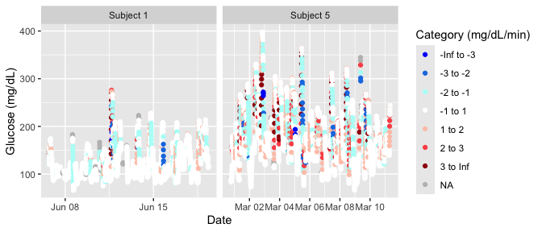

```r
plot_roc(example_data_5_subject, subjects = c("Subject 1", "Subject 5"))
```

The next figure shows a side by side comparison of rate of change histogram plots for the same subjects. Once again, the colors show in what direction and how quickly the glucose is changing. The histogram plots allow one to immediately assess the variation in rate of change. Extreme values on either end of the histogram indicate very rapid rises or drops in glucose - a high degree of local variability. Here, Subject 1 once again shows lower glucose variability by having a narrower histogram with most values falling between -2 mg/dl/min and 2 mg/dl/min. Subject 5 has a shorter, more widely distributed histogram indicating greater glucose variability.

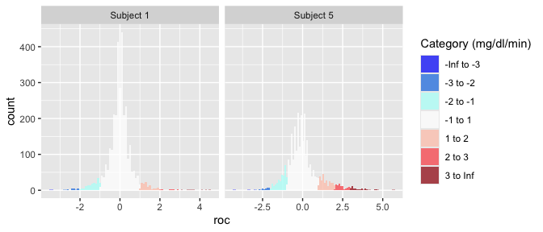

```r
hist_roc(example_data_5_subject, subjects = c("Subject 1", "Subject 5"))
```